# Comparative Effectiveness and Safety of Direct-acting Oral Anticoagulants and Warfarin in Patients with Venous Thromboembolism and Active Cancer: An Observational Analysis - ScienceDirect

## Cited By (2)

## Figures (6)

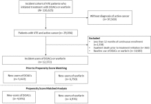

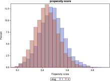

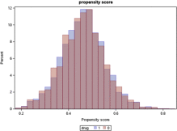

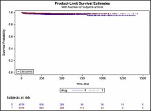

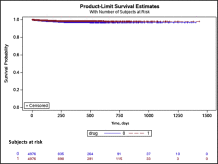

## [Clinical Therapeutics](https://www.sciencedirect.com/journal/clinical-therapeutics)

[Volume 42, Issue 9](https://www.sciencedirect.com/journal/clinical-therapeutics/vol/42/issue/9), September 2020, Pages e161-e176

# Comparative Effectiveness and Safety of Direct-acting Oral Anticoagulants and Warfarin in Patients with Venous Thromboembolism and Active Cancer: An Observational Analysis

https://doi.org/10.1016/j.clinthera.2020.06.022[Get rights and content](https://s100.copyright.com/AppDispatchServlet?publisherName=ELS&contentID=S0149291820303325&orderBeanReset=true)

## Highlights

**•**

There is limited evidence to support the use of DOACs in patients with cancer.

**•**

This was a retrospective cohort study of patients with VTE and cancer.

**•**

In a cohort of 9952 patients, DOACs was associated with a lower risk of VTE and major bleeding.

**•**

DOACs can be an effective and safe alternative to warfarin for the secondary prevention of VTE in patients with active cancer who are unwilling or unable to use LMWH.

## Abstract

### Purpose

There is limited evidence to support the use of direct-acting [oral anticoagulants](https://www.sciencedirect.com/topics/medicine-and-dentistry/antithrombotic) (DOACs) in patients with [venous thromboembolism](https://www.sciencedirect.com/topics/medicine-and-dentistry/venous-thromboembolism) (VTE) and active cancer. This study aimed to assess the effectiveness of DOACs versus warfarin for the prevention of recurrent VTE and major bleeding events in patients with VTE and active cancer.

### Methods

We identified patients with incident VTE and active cancer who newly initiated treatment with DOACs or warfarin from Truven Health MarketScan Commercial Claims and Medicare supplemental databases. Patients were followed up from treatment initiation (index date) until the occurrence of >7-day gap in treatment, the start of the study comparator, an outcome of interest (recurrent VTE or major bleeding), inpatient death, disenrollment, or end of the study period, whichever occurred first. We controlled for [confounders](https://www.sciencedirect.com/topics/pharmacology-toxicology-and-pharmaceutical-science/confounder) via [propensity score matching](https://www.sciencedirect.com/topics/medicine-and-dentistry/propensity-score-matching) and estimated the hazard ratios (HRs) using Cox [proportional hazards regression models](https://www.sciencedirect.com/topics/medicine-and-dentistry/proportional-hazards-model).

### Findings

A total of 9952 patients were included in the matched cohort (4976 DOACs users and 4976 warfarin users). Patient characteristics were well balanced after matching. We observed a lower incidence of recurrent VTE (3 vs 5 per 100 person-years) and major bleeding events (2 vs 3 per 100 person-years) in the DOAC group compared to warfarin group, respectively. In Cox regression models, use of DOACs (vs warfarin) was associated with a lower risk of recurrent VTE (hazard ratio (HR), 0.59; 95% CI, 0.42–0.82) and major bleeding events (HR, 0.64; 95% CI, 0.44–0.94).

### Implications

On the basis of our findings, among patients with VTE and active cancer, DOACs offer superior effectiveness with a lower risk of bleeding when compared with warfarin for the secondary prevention of VTE.

## Key words

cancer

DOACs

safety

thrombosis

venous thromboembolism

warfarin

## Introduction

[Venous thromboembolism](https://www.sciencedirect.com/topics/medicine-and-dentistry/venous-thromboembolism) (VTE), including [pulmonary embolism](https://www.sciencedirect.com/topics/medicine-and-dentistry/pulmonary-embolism) (PE) and [deep vein thrombosis](https://www.sciencedirect.com/topics/medicine-and-dentistry/deep-vein-thrombosis) (DVT), affects 200,000 individuals each year, incurring substantial societal and economic burden.<sup>1</sup> Risk of VTE increases with age, use of estrogen, prolonged immobility, major trauma, and cancer, with the latter accounting for approximately 20% of VTE cases.<sup>2</sup><sup>,</sup><sup>3</sup> Compared with patients with VTE without cancer, those with cancer have higher rates of recurrent events and adverse bleeding complications,<sup>4</sup> even with standard anticoagulation regimens.<sup>5</sup> This finding can be partially explained by complications related to factors such as surgical interventions, chemotherapy, and prolonged immobilization.<sup>6</sup>

The American College of Chest Physicians guidelines recommend low-molecular-weight heparin (LMWH) for secondary prevention of VTE in patients with cancer, yet most such patients are treated with [vitamin K antagonists](https://www.sciencedirect.com/topics/medicine-and-dentistry/vitamin-k-antagonist) (ie, warfarin) or direct-acting [oral anticoagulants](https://www.sciencedirect.com/topics/medicine-and-dentistry/antithrombotic) (DOACs) in routine clinical practice.<sup>7</sup><sup>,</sup><sup>8</sup> Because long-term treatment is recommended in patients with cancer, practical issues with the use of LMWH, including cost, [route of administration](https://www.sciencedirect.com/topics/pharmacology-toxicology-and-pharmaceutical-science/route-of-administration), and quality of life, make other alternatives (eg, DOACs and vitamin K antagonists) an attractive option for the treatment of patients with cancer-related VTE.<sup>9</sup> Although warfarin is inexpensive relative to other anticoagulants, drugs, including anticancer medications or chemotherapy, may interact with warfarin, which can lead to wide fluctuation in the international normalized ratio.<sup>6</sup><sup>,</sup><sup>10</sup>

DOACs (eg, apixaban, rivaroxaban, and dabigatran) are administered orally, do not require frequent monitoring, and are less susceptible to drug–drug or drug–food interactions.<sup>11</sup> However, there is limited evidence to guide the selection between DOACs and vitamin K antagonists within this population. Patients with cancer and VTE are often underrepresented in [randomized clinical trials](https://www.sciencedirect.com/topics/medicine-and-dentistry/randomized-clinical-trial) (RCTs), accounting for <5% of patients enrolled in these trials.<sup>9</sup> Furthermore, the evidence generated from a meta-analysis of RCTs, which was limited by the small sample size, found no differences in the risk of recurrent VTE and major bleeding between DOACs and warfarin.<sup>9</sup>

Therefore, we primarily aimed to (1) assess the effectiveness of DOACs versus warfarin for the prevention of recurrent VTE and (2) examine the risk of major bleeding between DOACs and warfarin among patients with VTE and active cancer. Secondarily, we aimed to assess the comparative effectiveness and safety of the individual DOACs compared with warfarin among patients with VTE and active cancer.

## Methods

### Data Source

This was a retrospective [cohort analysis](https://www.sciencedirect.com/topics/medicine-and-dentistry/cohort-analysis) using data from Truven Health MarketScan Commercial Claims and Medicare supplemental insurance between January 2013 and December 2016. The commercial data include employer-based health care coverage of employees and their dependents, representing >57 million covered lives. The Medicare supplemental files represent retirees who are covered by Medicare supplemental insurance. The database provides information on inpatient admissions, outpatient visits, prescription claims, enrollment, and health expenditures. The data are deidentified and compliant with the Health Insurance Portability and Accountability Act of 1996.

### Study Design and Participants

An incident disease, new-user cohort was created by selecting patients with newly diagnosed [VTE](https://www.sciencedirect.com/topics/medicine-and-dentistry/venous-thromboembolism) (ie, no prior diagnosis of VTE or use of [anticoagulants](https://www.sciencedirect.com/topics/medicine-and-dentistry/antithrombotic) within a 12-month lookback period) who initiated anticoagulation treatment within 30 days of their first VTE diagnosis. Patients were selected between January 2014 and November 2016 but followed up through December 2016 (Figure). We restricted the cohort to patients with active cancer who were new users at the time of their first VTE to avoid the bias that resulted from the inclusion of prevalent users, such as the underascertainment of events that occur early in treatment.<sup>12</sup> VTE was defined based on the presence of diagnoses of [DVT](https://www.sciencedirect.com/topics/medicine-and-dentistry/deep-vein-thrombosis) or [PE](https://www.sciencedirect.com/topics/medicine-and-dentistry/pulmonary-embolism) presenting on inpatient discharge claims or outpatient claims (2 diagnoses within 1 year). *[International Classification of Diseases](https://www.sciencedirect.com/topics/medicine-and-dentistry/international-classification-of-diseases)**, Ninth Revision* (ICD-9) and *International Classification of Diseases, Tenth Revision* (ICD-10) codes for VTE diagnosis, (ICD-9: 415.1, 451.1, 453.2, 453.4, 453.5, 453.8, 453.9; ICD-10: I80.2, I80.3, I80.1, I82.8, I80.9, I82.9, I80.8, O22.3, O22.9, O87.1, I26.9, I26.0) were validated previously.<sup>13</sup> We considered the date of the first claim to be the diagnosis date of VTE (ie, first of inpatient claims or the earliest date of 2 outpatient claims if VTE was captured based on 2 outpatient claims within 1 year).

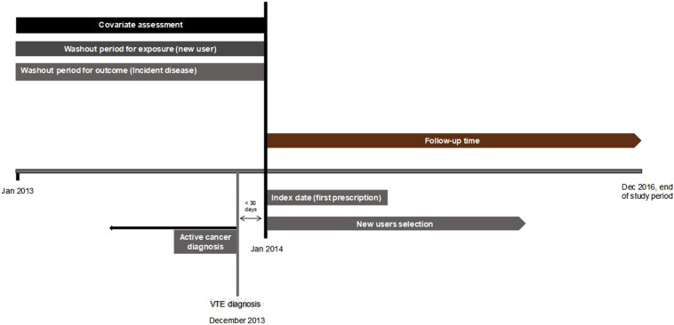

Figure. Study design. VTE = venous thromboembolism.

Among eligible patients, we identified those with diagnoses of active cancer based on the presence of a cancer diagnosis (any position) within the 6 months preceding their first VTE diagnosis. Patients were also required to be treated with radiotherapy, surgery, or chemotherapy.<sup>14</sup>

### Exposure and Covariates

Exposure was defined by the anticoagulant dispensed on the index date. Patients were classified into 2 groups: new users of DOACs (apixaban, rivaroxaban, dabigatran) or new users of warfarin. We did not have an adequate sample size to evaluate edoxaban because of its recent introduction into the US market. We selected warfarin as the active comparator because (1) warfarin remains the most widely used anticoagulant and (2) treatment guidelines at the time of the study (January 2013 to December 2016) used to give preference to warfarin in patients with cancer-related VTE. Patients were considered continuously exposed as long as they continued to refill their prescriptions, allowing a gap of ≤7 days between refills. We excluded patients who initiated use of DOACs and warfarin on the same date and those with <12 months of continuous enrollment in medical and pharmacy benefits before treatment initiation.

[Confounders](https://www.sciencedirect.com/topics/pharmacology-toxicology-and-pharmaceutical-science/confounder) were prespecified and identified from prior studies that evaluated the risk of recurrent VTE in patients with VTE or major bleeding in patients receiving anticoagulants.15, 16, 17, 18 Covariates included demographic characteristics, baseline measures of [health care utilization](https://www.sciencedirect.com/topics/medicine-and-dentistry/health-care-utilization) (eg, total number of outpatient visits during the prior year), baseline drug exposure (eg, nonsteroidal anti-inflammatory drugs, angiotensin-converting enzyme inhibitors, aspirin, and β-blockers), baseline comorbidities (eg, [ischemic heart disease](https://www.sciencedirect.com/topics/medicine-and-dentistry/ischemic-heart-disease), myocardial infarction, and chronic kidney disease), and the type of cancer treatment during baseline (chemotherapy, radiotherapy, and surgery). Because certain types of cancers may increase the risk of VTE, we classified cancer into risk categories as very high-risk for VTE (stomach, pancreas, and brain), high risk for VTE (lung, lymphoma, gynecologic, bladder, testicular, and renal), and low risk for VTE (thyroid, prostate, oral, leukemia, larynx, kidney, esophagus, colon, breast, and bone).<sup>19</sup><sup>,</sup><sup>20</sup> This classification is based on the Khorana risk score for the prediction of VTE in patients with cancer.<sup>20</sup> In addition, because bleeding is more common in patients with [gastrointestinal cancers](https://www.sciencedirect.com/topics/pharmacology-toxicology-and-pharmaceutical-science/digestive-system-cancer), we classified patients into 2 groups: gastrointestinal cancers and nongastrointestinal cancers.<sup>21</sup>

### Study Outcomes

The primary outcomes of interest were recurrent VTE and major bleeding events presenting on hospital discharge diagnosis (primary disposition only). Recurrent VTE events, DVT and PE, were identified based on the presence of primary discharge diagnosis indicative of VTE. This definition, which has been validated in inpatient and ambulatory care administrative databases, was found to have a positive predictive value between 73.3% and 83.1%.<sup>22</sup> The major bleeding outcome included a composite of [intracranial hemorrhage](https://www.sciencedirect.com/topics/medicine-and-dentistry/cerebral-hemorrhage), [gastrointestinal bleeding](https://www.sciencedirect.com/topics/medicine-and-dentistry/gastrointestinal-bleeding), and other major bleeding events. The ICD-9 and ICD-10 codes for major bleeding were used and validated in prior studies.<sup>23</sup><sup>,</sup><sup>24</sup>

Follow-up started from the date of the first prescription (index date) until (1) discontinuation of index medication (ie, presence of a gap >7 days in therapy); (2) start of the study comparator (ie, a DOAC user starts warfarin therapy); (3) an outcome of interest (recurrent VTE or major bleeding); (4) inpatient death; (5) disenrollment defined as the presence of a gap ≥31 days in health care coverage; or (6) end of the study period (December 2016), whichever occurred first. For the secondary analysis, switching among the individual DOACs terminated follow-up because we aimed to assess the comparative effectiveness and safety of the individual DOACs (apixaban, rivaroxaban, and dabigatran) compared with warfarin.

### Statistical Analysis

We summarized patients’ baseline demographic and clinical characteristics and assessed the differences between users of DOACs and warfarin via absolute standardized differences. We used the [propensity score matching](https://www.sciencedirect.com/topics/medicine-and-dentistry/propensity-score-matching) (PSM) method to reduce the effect of measured confounders. Incident users of DOACs were 1:1 matched to an incident user of warfarin based on a caliper of 0.01. We used Cox [proportional hazards models](https://www.sciencedirect.com/topics/medicine-and-dentistry/proportional-hazards-model) to estimate the hazard ratios (HRs), and the proportional hazards assumption was tested using Schoenfeld residuals.

In the subgroup analysis, we stratified the primary analysis by age (<65 vs ≥ 65 years), cancer-related VTE risk category (very high risk for VTE, high risk for VTE, or low risk for VTE) for the recurrent VTE outcome, and gastrointestinal cancers versus non-gastrointestinal cancers for the major bleeding outcome. We performed the matching again within each of the selected subgroups to preserve the balance in baseline characteristics (eg, within patients aged <65 years). We conducted sensitivity analyses to examine the robustness of the study findings. All analyses were performed using SAS software, version 9.4 (SAS Institute Inc, Cary, North Carolina).

## Results

A flow diagram of the study population is presented in Supplemental Figure 1. We identified a total of 5622 new users of DOACs and 6750 new users of warfarin before [PSM](https://www.sciencedirect.com/topics/medicine-and-dentistry/propensity-score-matching) (Table I and Supplemental Figure 2). After 1:1 matching, a total of 9952 patients were included in the matched cohort (4976 DOAC users and 4976 warfarin users) (Table II and Supplemental Figure 3). After PSM, patients’ demographic and clinical characteristics were well balanced between the DOAC and warfarin groups, including mean age (64.2 vs 64.3 years), proportion of men (49.2% vs 49.7%), history of bleeding (17.9% vs 18.1%), [chronic kidney disease](https://www.sciencedirect.com/topics/medicine-and-dentistry/chronic-kidney-disease) (15.6% vs 16.0%), and use of antiplatelet (5.5% vs 5.6%). All absolute standardized differences were <0.1. In addition, there was an equal distribution of cancer types between the 2 groups (Supplemental Table I).

Table I. Demographic and clinical characteristics of new users of DOACs and warfarin before propensity score matching.∗

[output not shown]

ACEIs = angiotensin-converting enzyme inhibitors; CKD = chronic kidney disease; COX = [cyclooxygenase](https://www.sciencedirect.com/topics/medicine-and-dentistry/prostaglandin-synthase); DOACs = direct-acting oral anticoagulants; HAS-BLED = hypertension, abnormal renal/liver function (1 or 2 points), stroke, bleeding history or predisposition, labile international normalized ratio, elderly (>65 years of age), drugs/alcohol concomitantly (1 or 2 points); PPIs = proton-pump inhibitors; [NSAIDs](https://www.sciencedirect.com/topics/medicine-and-dentistry/nonsteroid-antiinflammatory-agent) = nonsteroidal anti-inflammatory drugs; [SSRIs](https://www.sciencedirect.com/topics/medicine-and-dentistry/selective-serotonin-reuptake-inhibitor) = selective serotonin reuptake inhibitors; STD = standardized difference.

**∗**

Data are presented as number (percentage) of patients unless otherwise indicated.

Table II. Demographic and clinical characteristics of new users of DOACs and warfarin after propensity score matching.<sup>∗</sup>

[output not shown]

ACEIs = angiotensin-converting enzyme inhibitors; CKD = chronic kidney disease; COX = [cyclooxygenase](https://www.sciencedirect.com/topics/medicine-and-dentistry/prostaglandin-synthase); DOACs = direct-acting oral anticoagulants; PPIs = [proton pump inhibitors](https://www.sciencedirect.com/topics/medicine-and-dentistry/proton-pump-inhibitor); NSAIDs = nonsteroidal anti-inflammatory drugs; [SSRIs](https://www.sciencedirect.com/topics/medicine-and-dentistry/selective-serotonin-reuptake-inhibitor) = selective serotonin reuptake inhibitors; STD = standardized difference.

**∗**

Data are presented as number (percentage) of patients unless otherwise indicated.

### Recurrent VTE

A Kaplan–Meier curve in the matched sample and the incidence rates of recurrent VTE are presented in Supplemental Figure 4 and Table III. After adjustment, the use of DOACs was associated with a lower risk of recurrent VTE compared with warfarin (HR, 0.59; 95% CI, 0.42–0.82). The results from the prespecified subgroup analyses were consistent with the primary analysis when stratifying by age (*P* = 0.39 for interaction), cancer VTE-related risk category (P = 0.32 for interaction), and within the individual DOACs, including apixaban (vs warfarin) (HR, 0.32; 95% CI, 0.12–0.88) and rivaroxaban (vs warfarin) (HR, 0.68; 95% CI, 0.49–0.97) (Table III, Table IV). We were unable to examine dabigatran because of the limited sample size (n = 95).

Table III. Risk of recurrent venous thromboembolism and major bleeding with DOACs compared with warfarin in propensity score–matched analyses.

| Medications | No. of Patients | No. of Pearson-years | No. of Events | Crude Incidence per 100 Person-years | HR (95% CI) |
| --- | --- | --- | --- | --- | --- |
| Recurrent VTE |  |  |  |  |  |
| DOACs | 4976 | 1954 | 56 | 3 | 0.59 (0.42–0.82) |
| Warfarin | 4976 | 1957 | 96 | 5 | Reference |
| Secondary analysis |  |  |  |  |  |
| Apixaban | 975 | 332 | 5 | 2 | 0.32 (0.12–0.88) |
| Warfarin | 975 | 392 | 16 | 4 | Reference |
| Rivaroxaban | 4204 | 1674 | 55 | 3 | 0.68 (0.49, 0.97) |
| Warfarin | 4204 | 1609 | 80 | 5 | Reference |
| Major bleeding |  |  |  |  |  |
| DOACs | 4976 | 1963 | 43 | 2 | 0.64 (0.44–0.94) |
| Warfarin | 4976 | 1961 | 68 | 3 | Reference |
| Secondary analysis |  |  |  |  |  |
| Apixaban | 975 | 352 | 5 | 1 | 0.48 (0.17–1.39) |
| Warfarin | 975 | 303 | 11 | 4 | Reference |
| Rivaroxaban | 4204 | 1687 | 37 | 2 | 0.65 (0.43, 0.98) |
| Warfarin | 4204 | 1612 | 56 | 3 | Reference |

DOACs = direct-acting oral anticoagulants; HR = hazard ratio; VTE = venous thromboembolism.

Table IV. Risk of recurrent VTE and major bleeding events with DOACs versus warfarin in propensity score–matched subgroup analyses.

[output not shown]

DOACs = direct acting oral anticoagulants; GI = gastrointestinal; HR = hazard ratio; VTE = venous thromboembolism.

### Incident Bleeding

A Kaplan–Meier curve in the matched sample and the incidence rates of major bleeding are presented in Supplemental Figure 5 and Table III. After adjustment, the use of DOACs was associated with a lower risk of major bleeding compared with warfarin (HR, 0.64; 95% CI, 0.44–0.94) (Table III). The results from the prespecified subgroup analyses were consistent with the primary analysis when stratifying by age (*P* = 0.98 for interaction), cancer type, including [gastrointestinal cancer](https://www.sciencedirect.com/topics/pharmacology-toxicology-and-pharmaceutical-science/digestive-system-cancer) and nongastrointestinal cancer (P = 0.79 for interaction), and across the individual DOACs, including rivaroxaban (vs warfarin) (HR, 0.65; 95% CI, 0.43–0.98) and apixaban (vs warfarin) (HR, 0.48; 95% CI, 0.17–1.39), although the latter comparison was not statistically significant (Table III, Table IV).

## Discussion

In this population-based analysis of patients with VTE and active cancer who were not previously treated with anticoagulants, the use of DOACs was associated with a lower risk of recurrent VTE and major bleeding events compared with warfarin. This association remained consistent when comparing rivaroxaban and warfarin and when comparing apixaban and warfarin, although the low number of events in the latter comparison for the major bleeding outcome resulted in a wide CI crossing the null. We were not able to assess risks and benefits of dabigatran (n = 95) and edoxaban (n = < 10) because of the limited sample size.

Patients with active cancer are at an increased risk for VTE, and the selection of anticoagulant in this population remains a challenge in part because of the small proportion of patients with cancer who were included in [RCTs](https://www.sciencedirect.com/topics/medicine-and-dentistry/randomized-clinical-trial).<sup>25</sup> Treatment guidelines consider LMWH to be the treatment of choice for the prevention of cancer-related VTE but note that warfarin or a DOAC may be a reasonable alternative in patients who refuse or have compelling reasons to avoid LMWH, such as pain related to injections, inconvenience related to LMWH administration, or the cost of LMWH therapy.<sup>8</sup><sup>,</sup><sup>25</sup>

Despite the steady increase in the use of DOACs among the general VTE population, their uptake in patients with cancer-associated VTE remains limited, presumably because of the relative paucity of evidence. Recently, DOACs were compared with LMWH among cancer patients in RCTs.<sup>26</sup><sup>,</sup><sup>27</sup> The Hokusai VTE Cancer trial found that edoxaban was noninferior to LMWH for the prevention of recurrent VTE but was associated with higher bleeding risk.<sup>27</sup> Similarly, the [Anticoagulation Therapy](https://www.sciencedirect.com/topics/medicine-and-dentistry/anticoagulant-therapy) in Selected Cancer Patients at Risk of Recurrence of Venous Thromboembolism (SELECT-D) trial reported that rivaroxaban, compared with LMWH, was associated with a lower risk of recurrent VTE (HR, 0.43; 95% CI, 0.19–0.99) but a higher risk of clinically relevant nonmajor bleeding (HR, 3.76; 95% CI, 1.63–8.69). The results from these trials prompted the National Comprehensive Cancer Network to include DOACs in their most recent updated version of treatment guidelines as a second-line treatment option behind LMWH for the prevention of VTE.<sup>28</sup> Although the recommendations encourage the use of edoxaban in combination with LMWH (Level of Recommendation: A), the use of other DOACs, such as apixaban and rivaroxaban, is recommended when patients refuse or have contraindications for LMWH.<sup>28</sup>

There are several limitations of the current analysis. First, although the study adjusted for several measured [confounders](https://www.sciencedirect.com/topics/pharmacology-toxicology-and-pharmaceutical-science/confounder), information on laboratory measures (eg, international normalized ratio), disease risk factors (eg, immobility), and over-the-counter medications (eg, aspirin) were not available in the current data. Second, there is the potential of coding error when specifying [ICD codes](https://www.sciencedirect.com/topics/medicine-and-dentistry/international-classification-of-diseases) in administrative databases. As a result, it is possible that VTE recurrence events identified using discharge diagnosis code might be originated from previous VTE events (rather than new recurrence), which would have resulted in an overestimation of the risk of recurrent VTE. Thus, we used an outcome definition based on primary hospital discharge diagnosis only, which has been validated in previous studies. In addition, any misclassification is likely nondifferential between the DOAC and warfarin groups.

Third, although we used the PSM to mimic randomization, the potential for selection bias remains, for example, if a physicians' choice to prescribe DOACs versus warfarin was predicated on their perception of a patient's baseline disease risk. However, we expect this to have a minimal effect on the observed estimates because most of the baseline covariates, including a number of well-known risk factors for recurrent VTE and bleeding, were comparable between the treatment groups even before PSM. Fourth, although the risk of VTE may vary between primary and [secondary cancer](https://www.sciencedirect.com/topics/medicine-and-dentistry/metastatic-carcinoma), we were not able to differentiate between the treatment groups because of the nature of the database used in this study. Fifth, the current data are representative of the patients with VTE who have active cancer and are covered by commercial or Medicare supplemental insurance. The study results are applicable for secondary prevention of VTE (ie, recurrent VTE) rather than primary prevention in patients with cancer.

Despite these limitations, the present study has several strengths. First, we only included treatment-naive patients and used a robust adjustment method to minimize differences in baseline covariates. Second, we had a large sample of patients with cancer and VTE, which allowed for the assessment of the risks and benefits of the individual DOACs (eg, apixaban and rivaroxaban).

## Conclusion

On the basis of our findings, DOACs offer superior effectiveness for the prevention of recurrent VTE and have a lower risk of bleeding when compared with warfarin among patients with VTE and active cancer.

## Disclosures

The authors have indicated that they have no conflicts of interest regarding the content of this article.

## Acknowledgments

This research received no external funding.